# model_features

```python
import numpy as np
import pandas as pd
import sys
sys.path.append("..")
```

```python
from utils import config, io, models
```

```python
from matplotlib import pyplot as plt
from sklearn.model_selection import train_test_split
from sklearn.linear_model import LinearRegression
from sklearn.ensemble import GradientBoostingRegressor
from sklearn.metrics import r2_score, mean_squared_error
```

```python
from joblib import dump, load
```

We have trained the model with all the indicators we have plotted the importance each indicator has in the prediction of the GDP growth.

```python
gbm_model=load('gbmmodel_Fullest.joblib')
```

```python
importance=gbm_model.feature_importances_
```

```python
df=pd.DataFrame(importance)
df
```

|  | 0 |
| --- | --- |
| 0 | 1.440452e-03 |
| 1 | 1.023797e-05 |
| 2 | 3.227629e-05 |
| 3 | 5.027148e-04 |
| 4 | 5.041934e-03 |
| ... | ... |
| 1324 | 0.000000e+00 |
| 1325 | 0.000000e+00 |
| 1326 | 4.959973e-09 |
| 1327 | 0.000000e+00 |
| 1328 | 1.952923e-03 |

1329 rows × 1 columns

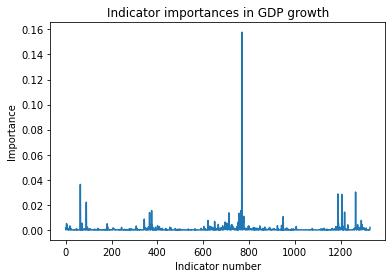

```python
fig, ax = plt.subplots()

ax.set_title("Indicator importances in GDP growth")
ax.set_ylabel("Importance")
ax.set_xlabel("Indicator number")

plt.plot(importance)
```

Based on the results of the graphic above we will now choose the 50 indicators that have most influence in the calculation of the GDP growth and we will save it in a CSV file to use it later to train the model.

```python
best=df[0].nlargest(50)
best
```

```
769     0.157709
64      0.036299
1265    0.030223
1188    0.028708
1205    0.028298
90      0.022067
375     0.015489
764     0.015407
1217    0.014223
366     0.013871
712     0.013610
757     0.013268
768     0.013102
756     0.011682
777     0.010828
```

[output cut: 36 more lines]

```python
best.to_csv("bestindicators.csv")
```

Now, we will see to which indicator each number corresponds in order to make an analysis of the influence the indicators have on GDP growth.

```python
indicators,data,num=models.fselection()
predictors=io.indicators(indicators,data,num)
predictors=predictors.fillna(0)
indexs=indicators['Unnamed: 0']
indexs=indexs.tolist()
names=predictors.columns.tolist()
indicators["Unnamed: 0"]=indicators["Unnamed: 0"]+1
final = [names[ind] for ind in indexs]
```

```
Selecting the best indicators...

Reading the SQL file...

Done

Getting list of countries...

Done

Do you want to use the selection of indicators predefined?
```

```
Indicators selected

Obtaining the data...

Data obtained
```

```python
final
```

```
['NY.GDP.MKTP.KD.ZG',
 'BX.KLT.DINV.WD.GD.ZS',
 'TM.VAL.MRCH.CD.WT',
 'SP.DYN.IMRT.IN',
 'SP.POP.GROW',
 'DC.DAC.GBRL.CD',
 'EN.ATM.CO2E.LF.KT',
 'NY.GDP.FRST.RT.ZS',
 'SP.URB.GROW',
 'EG.USE.COMM.GD.PP.KD',
 'NV.IND.TOTL.KD.ZG',
 'NY.GDP.DEFL.ZS',
 'NY.GDP.MKTP.KD',
 'NY.GDP.DEFL.KD.ZG',
 'NY.GDP.PCAP.KD.ZG',
 'SH.DYN.MORT',
 'EG.EGY.PRIM.PP.KD',
 'TX.VAL.MMTL.ZS.UN',
 'MS.MIL.TOTL.TF.ZS',
 'NY.GDP.PCAP.CN',
 'NE.CON.TETC.KD.ZG',
 'NY.ADJ.SVNX.GN.ZS',
 'NE.RSB.GNFS.ZS',
 'NY.GDP.PCAP.KN',
 'SP.DYN.LE00.FE.IN',
 'NY.GDP.PCAP.KD',
 'NV.AGR.TOTL.ZS',
 'CM.MKT.INDX.ZG',
 'AG.LND.AGRI.ZS',
 'DT.DOD.DSTC.IR.ZS',
 'NV.IND.MANF.KD.ZG',
 'NY.GDP.MKTP.CN',
 'NE.EXP.GNFS.KD.ZG',
 'TX.VAL.MRCH.HI.ZS',
 'TM.VAL.MRCH.RS.ZS',
 'EN.ATM.CO2E.PC',
 'TG.VAL.TOTL.GD.ZS',
 'NV.SRV.TETC.KD.ZG',
 'NY.ADJ.AEDU.GN.ZS',
 'EN.ATM.CO2E.KD.GD',
 'AG.LND.ARBL.HA.PC',
 'SH.DTH.IMRT',
 'NV.AGR.TOTL.KD.ZG',
 'EN.CO2.BLDG.ZS',
 'SE.XPD.SECO.ZS',
 'NY.GDP.MKTP.KN',
 'NE.GDI.TOTL.ZS',
 'AG.PRD.FOOD.XD',
 'SE.PRM.ENRL.TC.ZS',
 'NY.ADJ.AEDU.CD']
```

We have seen that the among the indexes that most influence the GDP growth there is not the Country indicator, but the GDP growth will change deppending on the Country we analise for sure. So we have changed the last indicator in the list for the Country indicator, which is already stored in the CSV.

```python
final.pop()
final.append("COUNTRYENC")
final
```

```
['NY.GDP.MKTP.KD.ZG',
 'BX.KLT.DINV.WD.GD.ZS',
 'TM.VAL.MRCH.CD.WT',
 'SP.DYN.IMRT.IN',
 'SP.POP.GROW',
 'DC.DAC.GBRL.CD',
 'EN.ATM.CO2E.LF.KT',
 'NY.GDP.FRST.RT.ZS',
 'SP.URB.GROW',
 'EG.USE.COMM.GD.PP.KD',
 'NV.IND.TOTL.KD.ZG',
 'NY.GDP.DEFL.ZS',
 'NY.GDP.MKTP.KD',
 'NY.GDP.DEFL.KD.ZG',
 'NY.GDP.PCAP.KD.ZG',
 'SH.DYN.MORT',
 'EG.EGY.PRIM.PP.KD',
 'TX.VAL.MMTL.ZS.UN',
 'MS.MIL.TOTL.TF.ZS',
 'NY.GDP.PCAP.CN',
 'NE.CON.TETC.KD.ZG',
 'NY.ADJ.SVNX.GN.ZS',
 'NE.RSB.GNFS.ZS',
 'NY.GDP.PCAP.KN',
 'SP.DYN.LE00.FE.IN',
 'NY.GDP.PCAP.KD',
 'NV.AGR.TOTL.ZS',
 'CM.MKT.INDX.ZG',
 'AG.LND.AGRI.ZS',
 'DT.DOD.DSTC.IR.ZS',
 'NV.IND.MANF.KD.ZG',
 'NY.GDP.MKTP.CN',
 'NE.EXP.GNFS.KD.ZG',
 'TX.VAL.MRCH.HI.ZS',
 'TM.VAL.MRCH.RS.ZS',
 'EN.ATM.CO2E.PC',
 'TG.VAL.TOTL.GD.ZS',
 'NV.SRV.TETC.KD.ZG',
 'NY.ADJ.AEDU.GN.ZS',
 'EN.ATM.CO2E.KD.GD',
 'AG.LND.ARBL.HA.PC',
 'SH.DTH.IMRT',
 'NV.AGR.TOTL.KD.ZG',
 'EN.CO2.BLDG.ZS',
 'SE.XPD.SECO.ZS',
 'NY.GDP.MKTP.KN',
 'NE.GDI.TOTL.ZS',
 'AG.PRD.FOOD.XD',
 'SE.PRM.ENRL.TC.ZS',
 'COUNTRYENC']
```

We know want to see to which name each indicator code corresponds in order to understand why are these factors the ones that most influenciate the GDP Growth.

```python
ind=io.ind_names()
ind_code=ind['IndicatorCode'].tolist()
ind_name=ind['IndicatorName'].tolist()
```

```python
for i in final:
    for j in ind_code:
        if i==j:
            print(i)
            final[final.index(i)]=ind_name[ind_code.index(j)]
```

```
NY.GDP.MKTP.KD.ZG
BX.KLT.DINV.WD.GD.ZS
TM.VAL.MRCH.CD.WT
SP.DYN.IMRT.IN
SP.POP.GROW
DC.DAC.GBRL.CD
EN.ATM.CO2E.LF.KT
NY.GDP.FRST.RT.ZS
SP.URB.GROW
EG.USE.COMM.GD.PP.KD
NV.IND.TOTL.KD.ZG
NY.GDP.DEFL.ZS
NY.GDP.MKTP.KD
NY.GDP.DEFL.KD.ZG
NY.GDP.PCAP.KD.ZG
SH.DYN.MORT
EG.EGY.PRIM.PP.KD
TX.VAL.MMTL.ZS.UN
MS.MIL.TOTL.TF.ZS
NY.GDP.PCAP.CN
NE.CON.TETC.KD.ZG
NY.ADJ.SVNX.GN.ZS
NE.RSB.GNFS.ZS
NY.GDP.PCAP.KN
SP.DYN.LE00.FE.IN
NY.GDP.PCAP.KD
NV.AGR.TOTL.ZS
CM.MKT.INDX.ZG
AG.LND.AGRI.ZS
DT.DOD.DSTC.IR.ZS
NV.IND.MANF.KD.ZG
NY.GDP.MKTP.CN
NE.EXP.GNFS.KD.ZG
TX.VAL.MRCH.HI.ZS
TM.VAL.MRCH.RS.ZS
EN.ATM.CO2E.PC
TG.VAL.TOTL.GD.ZS
NV.SRV.TETC.KD.ZG
NY.ADJ.AEDU.GN.ZS
EN.ATM.CO2E.KD.GD
AG.LND.ARBL.HA.PC
SH.DTH.IMRT
NV.AGR.TOTL.KD.ZG
EN.CO2.BLDG.ZS
SE.XPD.SECO.ZS
NY.GDP.MKTP.KN
NE.GDI.TOTL.ZS
AG.PRD.FOOD.XD
SE.PRM.ENRL.TC.ZS
```

```python
final
```

```
['GDP growth (annual %)',
 'Foreign direct investment, net inflows (% of GDP)',
 'Merchandise imports (current US$)',
 'Mortality rate, infant (per 1,000 live births)',
 'Population growth (annual %)',
 'Net bilateral aid flows from DAC donors, United Kingdom (current US$)',
 'CO2 emissions from liquid fuel consumption (kt)',
 'Forest rents (% of GDP)',
 'Urban population growth (annual %)',
 'Energy use (kg of oil equivalent) per $1,000 GDP (constant 2011 PPP)',
 'Industry, value added (annual % growth)',
 'GDP deflator (base year varies by country)',
 'GDP (constant 2005 US$)',
 'Inflation, GDP deflator (annual %)',
 'GDP per capita growth (annual %)',
 'Mortality rate, under-5 (per 1,000 live births)',
 'Energy intensity level of primary energy (MJ/$2011 PPP GDP)',
 'Ores and metals exports (% of merchandise exports)',
 'Armed forces personnel (% of total labor force)',
 'GDP per capita (current LCU)',
 'Final consumption expenditure, etc. (annual % growth)',
 'Adjusted net savings, excluding particulate emission damage (% of GNI)',
 'External balance on goods and services (% of GDP)',
 'GDP per capita (constant LCU)',
 'Life expectancy at birth, female (years)',
 'GDP per capita (constant 2005 US$)',
 'Agriculture, value added (% of GDP)',
 'S&P Global Equity Indices (annual % change)',
 'Agricultural land (% of land area)',
 'Short-term debt (% of total reserves)',
 'Manufacturing, value added (annual % growth)',
 'GDP (current LCU)',
 'Exports of goods and services (annual % growth)',
 'Merchandise exports to high-income economies (% of total merchandise exports)',
 'Merchandise imports by the reporting economy, residual (% of total merchandise imports)',
 'CO2 emissions (metric tons per capita)',
 'Merchandise trade (% of GDP)',
 'Services, etc., value added (annual % growth)',
 'Adjusted savings: education expenditure (% of GNI)',
 'CO2 emissions (kg per 2005 US$ of GDP)',
 'Arable land (hectares per person)',
 'Number of infant deaths',
 'Agriculture, value added (annual % growth)',
 'CO2 emissions from residential buildings and commercial and public services (% of total fuel combustion)',
 'Expenditure on secondary education (% of government expenditure on education)',
 'GDP (constant LCU)',
 'Gross capital formation (% of GDP)',
 'Food production index (2004-2006 = 100)',
 'Pupil-teacher ratio, primary',
 'COUNTRYENC']
```

A country’s gross domestic product or GDP is a measure of the size and health of its economy. We can see in the list that the factor that most influence has on the GDP growth according with our model is the GDP annual growth of other years. This makes absolute sense since we want our model to predict that value for the next year.

The second factor that most importance has on the prediction of the GDP growth is the Foreign direct investment or FDI. The FDI is an investment made by a firm or individual in one country into business interests located in another country. Generally, FDI takes place when an investor establishes foreign business operations or acquires foreign business assets in a foreign company.

In the third position we have the Merchandise imports indicator. International merchandise import statistics measure the quantity, value, origin, etc of goods which are brought into a country permanently. They provide information about a countries trading role within the global economy. That is why it will have to be account to predict the GDP growth.

Apart from that, the selected as best indicators also provide information about population, environmental impact, GDP factors etc.

We will now train the data using the gradient boosting method to analise the impact those indicators have on the GDP growth prediction.

```python
X_test=models.GBmodelTrain()
```

```
running gradient boosting for all countries...
Selecting the best indicators...

Reading the SQL file...

Done

Getting list of countries...

Done

Do you want to use the selection of indicators predefined?
```

[output not shown]

```python
X_test
```

| CountryCode | IndicatorCode Year | NY.GDP.MKTP.KD.ZG | BX.KLT.DINV.WD.GD.ZS | TM.VAL.MRCH.CD.WT | SP.DYN.IMRT.IN | SP.POP.GROW | DC.DAC.GBRL.CD | EN.ATM.CO2E.LF.KT | NY.GDP.FRST.RT.ZS | SP.URB.GROW | EG.USE.COMM.GD.PP.KD | ... | SH.DTH.IMRT | NV.AGR.TOTL.KD.ZG | EN.CO2.BLDG.ZS | SE.XPD.SECO.ZS | NY.GDP.MKTP.KN | NE.GDI.TOTL.ZS | AG.PRD.FOOD.XD | SE.PRM.ENRL.TC.ZS | NY.ADJ.AEDU.CD | COUNTRYENC |
| --- | --- | --- | --- | --- | --- | --- | --- | --- | --- | --- | --- | --- | --- | --- | --- | --- | --- | --- | --- | --- | --- | --- |
| 105 | 1968 | 6.544555 | 0.000000 | 1.028480e+10 | 32.0 | 0.631737 | 0.0 | 181784.191 | 0.000000 | 1.403955 | 0.000000 | ... | 29668.0 | 0.000000 | 19.493186 | 0.0 | 6.423085e+11 | 24.145629 | 83.850000 | 0.000000 | 0.000000e+00 | 105 |
| 197 | 1987 | 7.231269 | 5.619436 | 1.370000e+08 | 158.3 | 3.112712 | 3620000.0 | 498.712 | 10.728243 | 3.821719 | 0.000000 | ... | 26115.0 | 6.105890 | 0.000000 | 0.0 | 4.972333e+12 | 10.186010 | 54.480000 | 0.000000 | 1.206538e+07 | 197 |
| 122 | 1973 | 0.000000 | 0.000000 | 1.806130e+09 | 81.3 | 4.344959 | 0.0 | 4198.715 | 0.000000 | 9.934385 | 0.000000 | ... | 9418.0 | 0.000000 | 5.017301 | 0.0 | 0.000000e+00 | 0.000000 | 41.870000 | 25.634550 | 0.000000e+00 | 122 |
| 82 | 1982 | 4.200082 | 0.000000 | 5.000000e+07 | 0.0 | 2.079735 | 430000.0 | 143.013 | 25.989638 | 6.989741 | 0.000000 | ... | 0.0 | 0.000000 | 0.000000 | 0.0 | 2.021937e+11 | 28.259555 | 47.560000 | 22.565010 | 5.219946e+06 | 82 |
| 78 | 2003 | 11.058102 | 8.384307 | 1.141000e+09 | 25.5 | -0.647028 | 3410000.0 | 1716.156 | 0.201315 | -0.534253 | 152.583909 | ... | 1365.0 | 10.343817 | 15.705128 | 0.0 | 5.669334e+09 | 31.320712 | 110.940000 | 14.502910 | 1.237523e+08 | 78 |
| ... | ... | ... | ... | ... | ... | ... | ... | ... | ... | ... | ... | ... | ... | ... | ... | ... | ... | ... | ... | ... | ... | ... |
| 181 | 1995 | 4.075190 | 0.000000 | 0.000000e+00 | 0.0 | 0.923750 | 0.0 | 0.000 | 0.000000 | 1.084994 | 0.000000 | ... | 0.0 | -14.035088 | 0.000000 | 0.0 | 8.231985e+09 | 16.869285 | 116.960000 | 0.000000 | 2.337848e+09 | 181 |
| 235 | 1973 | 7.109958 | -0.431967 | 2.812440e+09 | 44.2 | 2.813100 | 250000.0 | 13384.550 | 0.217281 | 3.827308 | 0.000000 | ... | 18339.0 | 6.368086 | 5.478358 | 0.0 | 2.594541e+10 | 30.982659 | 42.400000 | 33.593550 | 7.878332e+08 | 235 |
| 25 | 1989 | 0.443844 | 0.000000 | 5.350000e+08 | 0.0 | 0.846659 | 60000.0 | 784.738 | 0.000000 | 0.843095 | 0.000000 | ... | 0.0 | 0.000000 | 0.000000 | 0.0 | 3.433615e+09 | 0.000000 | 111.840000 | 0.000000 | 3.957510e+07 | 25 |
| 95 | 1991 | 0.000000 | -0.051820 | 4.000000e+08 | 98.4 | 2.003229 | 40000.0 | 806.740 | 1.869327 | 5.893608 | 0.000000 | ... | 24334.0 | 0.000000 | 6.666667 | 0.0 | 0.000000e+00 | 24.367981 | 92.630000 | 0.000000 | 0.000000e+00 | 95 |
| 191 | 1988 | 8.558408 | 0.086676 | 3.284000e+10 | 96.5 | 2.278416 | 273560000.0 | 173005.393 | 2.127845 | 3.388927 | 0.000000 | ... | 3470351.0 | 12.593264 | 10.434558 | 0.0 | 0.000000e+00 | 22.664881 | 63.420435 | 40.526669 | 0.000000e+00 | 191 |

3780 rows × 51 columns

We have already trained our model to obtain the infortation we will use to see the impotance of some model features we have used. For that purpose we will use the shap package.

```python
import shap
```

```python
import os
from utils import config
```

```python
name = input("Write the name of the model for predicting, without the extension GBM.jlib")
fullname = name + 'GBM.joblib'
fullname = os.path.join(config.MODELS_PATH, name + 'GBM.joblib')
gbm_model = load(fullname)
```

```python
shap.initjs()
explainer = shap.TreeExplainer(gbm_model)
```

```python
%%time
# This operation takes a while
shap_values = explainer.shap_values(X_test)
```

```
Wall time: 59.6 s
```

We have obtained the shap values in the X_test to calculate the impact of each variable in each prediction. It will give us information about the decitions made by the model.

```python
shap.initjs()
shap.force_plot(explainer.expected_value, shap_values[0,:], X_test.iloc[0,:])
```

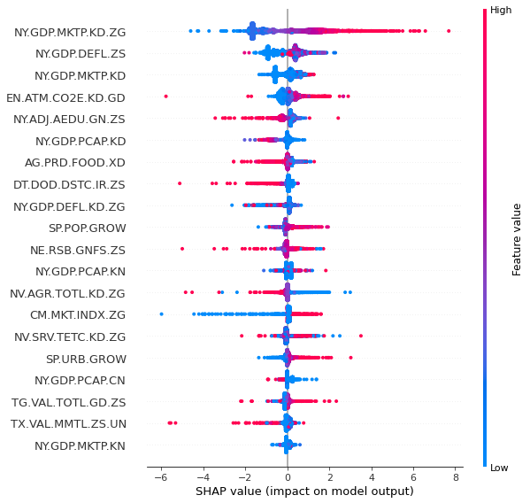

```python
shap.summary_plot(shap_values, X_test)
```

We will know analyse some of the features separately. We will start ploting the influence of the Country in the model.

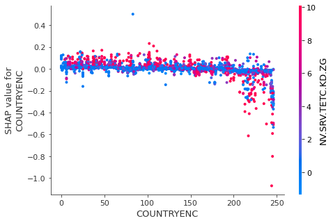

```python
shap.dependence_plot("COUNTRYENC", shap_values, X_test)
```

Vertical dispersion at a single value represents interaction effects with other features. In this case it is comparing the Country with the Services, etc., value added (annual % growth) for colouring. It can be seen that for most of the countries the Shap value remains almost the same. So maybe it was true that the country type didn't influence the model so much, and we shouldn't have enter it in the most influece indicator list.

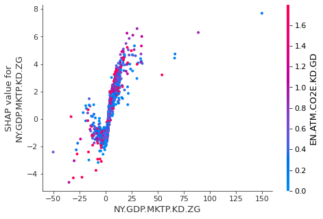

```python
shap.dependence_plot("NY.GDP.MKTP.KD.ZG", shap_values, X_test)
```

From the GDP growth indicator we can conclude that for negative values of the GDP growth the shap value decreases and for positive value of the GDP growth the Shap value increases. This makes sense because the greater the GDP growth the greater would be the predicted GDP value.

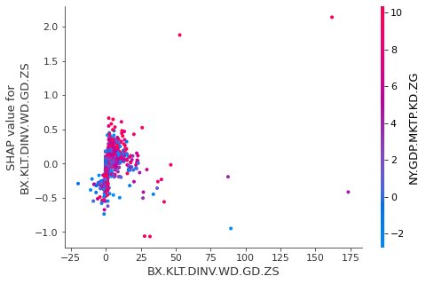

```python
shap.dependence_plot("BX.KLT.DINV.WD.GD.ZS", shap_values, X_test)
```

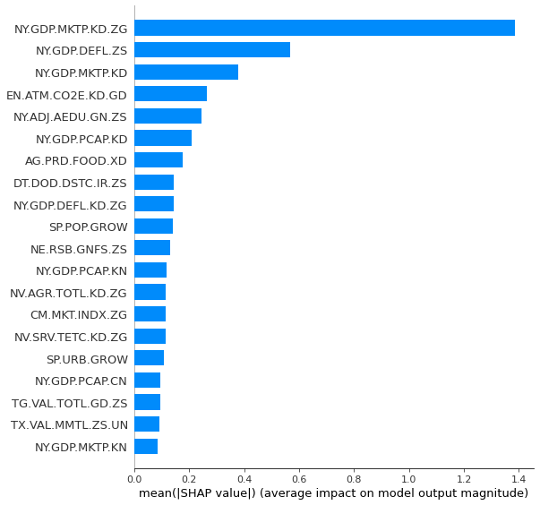

```python
shap.summary_plot(shap_values, X_test, plot_type="bar")
```

In conclusion we can see that the values that have most influence in the model are not sorted in the same order that the list of the 50 best indicators we had obtained by training the model with all the indicators. This can be because there are lots of empty parameters in the SQL file so that the model doesn't train properly enough.